# Univariate Plots Section

# Bivariate Plots Section

An overview of all the variables and their correlations are created:

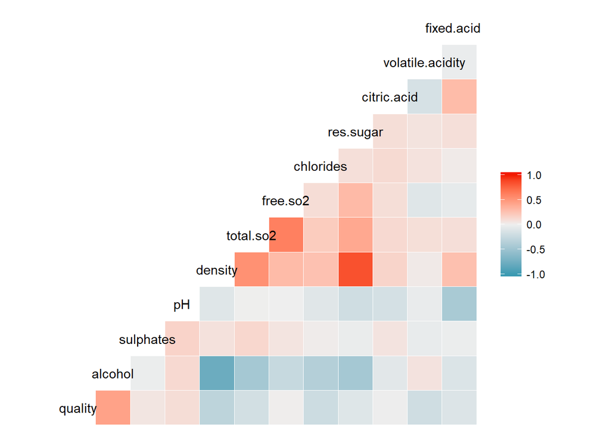

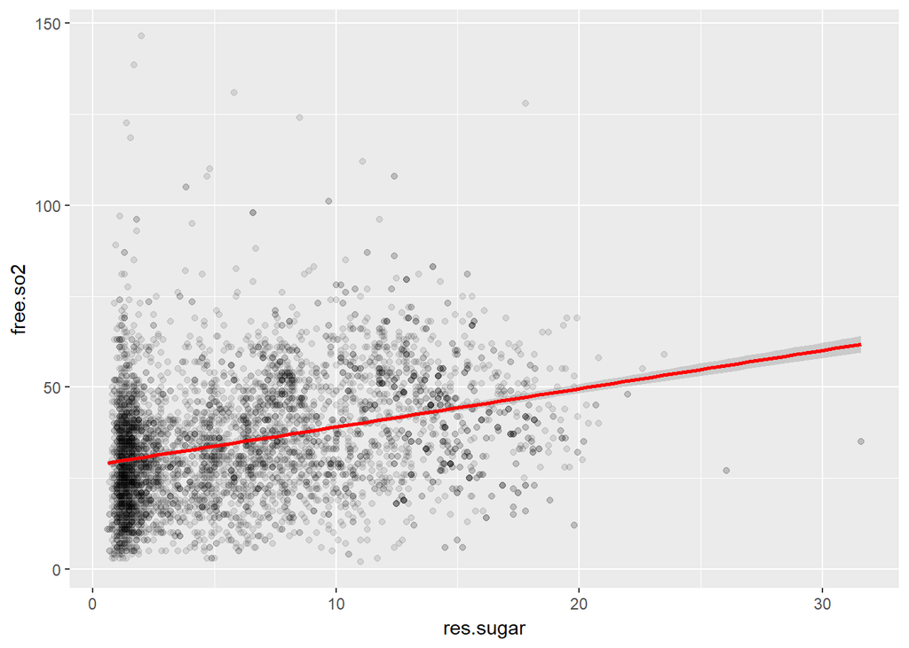

```
## [1] "Pearsons Correlation Coefficient: 0.316778"
```

An alpha value of 0.1 has been chosen to show the distribution of the data points. The free sulfur dioxide has a positive correlation of 0.32 with the residual sugar. There is a lot of wines with a very low amount of residual sugar.

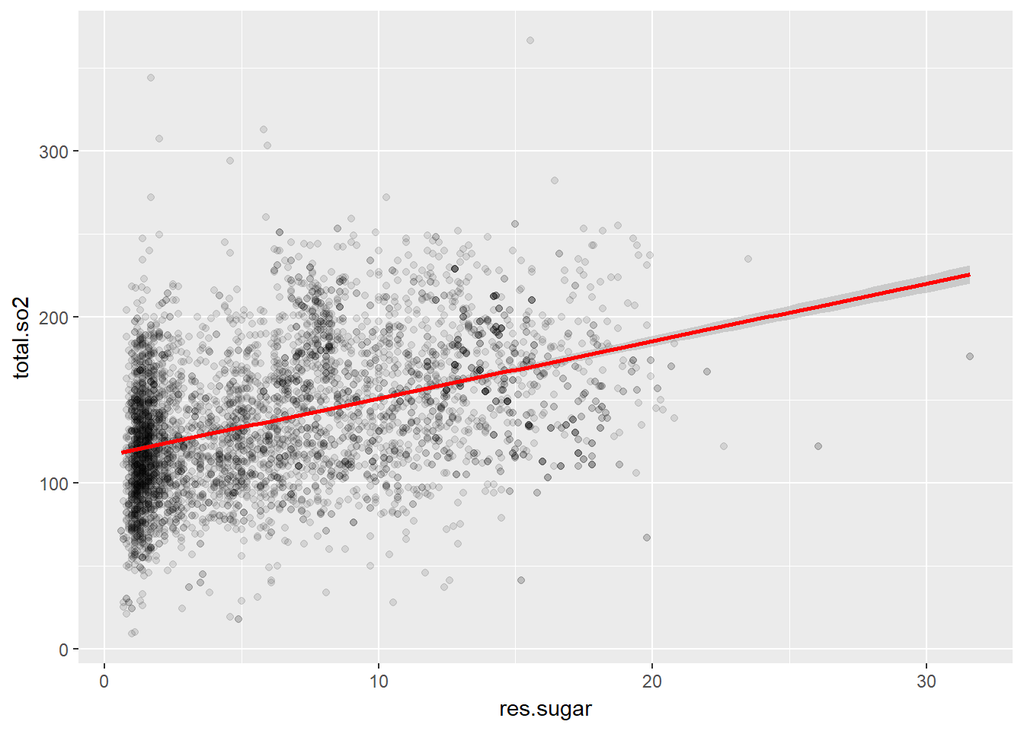

```
## [1] "Pearsons Correlation Coefficient: 0.409099"
```

The free and total sulfur dioxide behaves similarly when plotted against the residual sugar. For the total sulfur dioxide there is a positive correlation of 0.41 with the residual sugar.

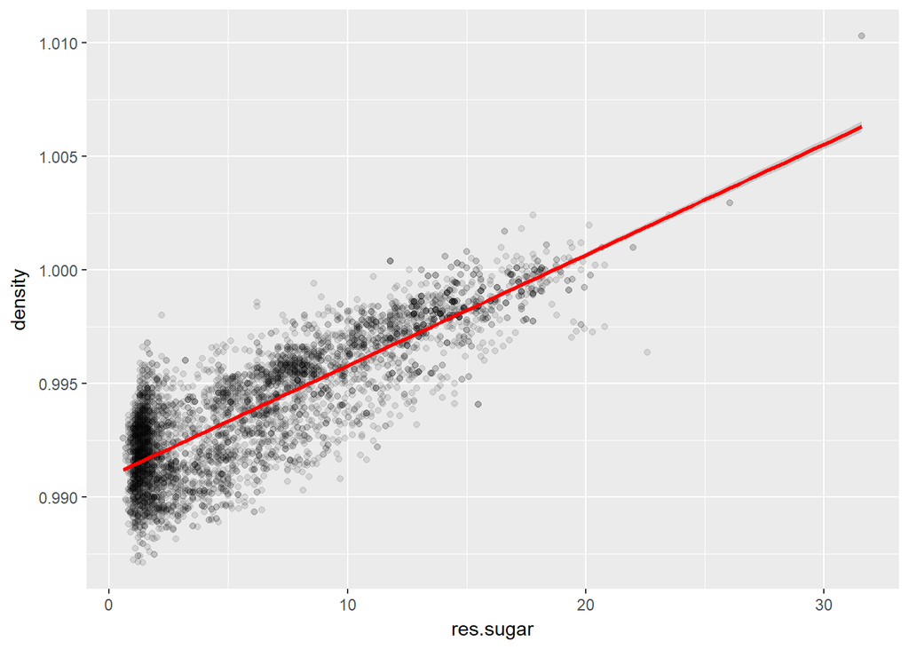

```
## [1] "Pearsons Correlation Coefficient: 0.833975"
```

The correlation between density and residual sugar is positive at 0.83, which is a very high value and indicates a strong correlation. This is also evident from the plot. The datapoints for a low amount of residual sugar is less spread out for the density when compared to the sulfur dioxide.

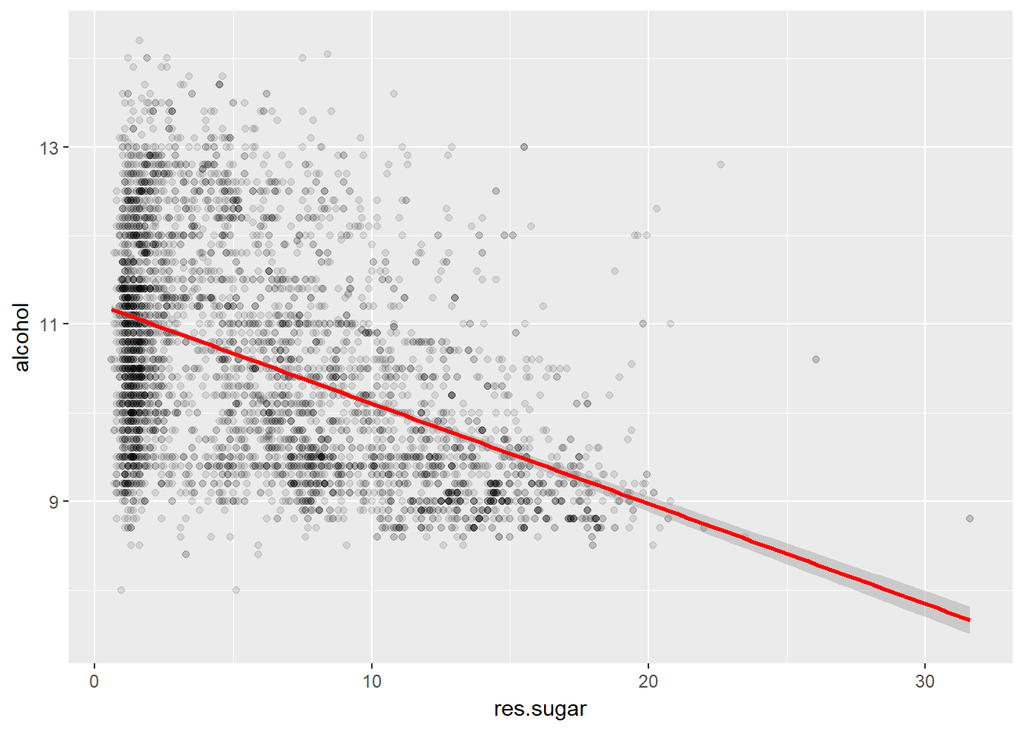

```
## [1] "Pearsons Correlation Coefficient: -0.459487"
```

There is a negative correlation of -0.46 between alcohol and residual sugar. There is a clear declining trend to the upper value of alcohol with increasing residual sugar.  
All the plots above here, investigates the residual sugar and the significant correlations found. The two first plots are the free and the total sulfur dioxide. Persons correlation yields 0.32 and 0.41 for these two plots, which could indicate a moderate correlation between these and residual sugar. Both have a lot of datapoints with very little residual sugar, but otherwise there seems to be a positive correlation.  
The residual sugar and density seems to be well correlated, with a positive Pearson correlation coefficient of 0.83.  
Residual sugar and alcohol also seems to show some correlation with a negative Pearson correlation coefficient of -0.46. All of these datasets shows that a lot of wines have very little residual sugar, but a correlation seems to be prevalent for an increasing amount of residual sugar.

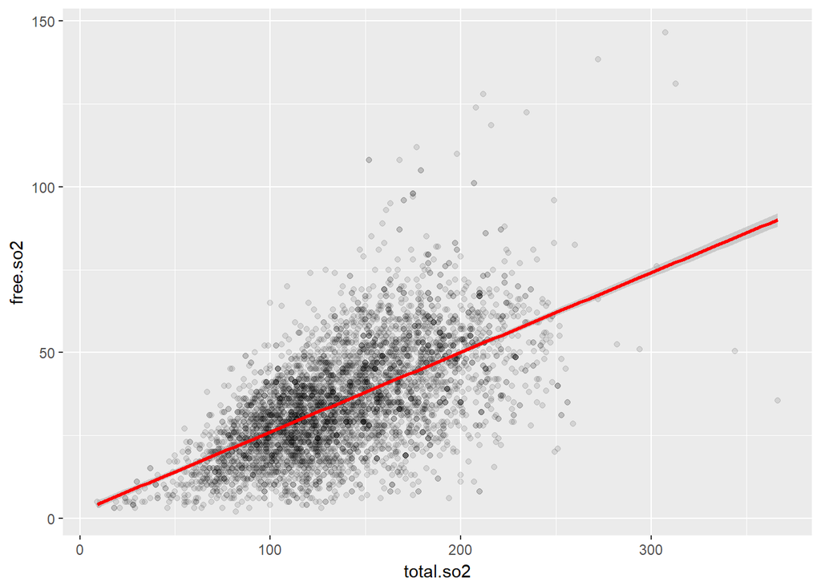

```
## [1] "Pearsons Correlation Coefficient: 0.611357"
```

There is a moderate to strong relationship between the free sulfur dioxide and the total sulfur dioxide with a positive correlation coefficient of 0.61.

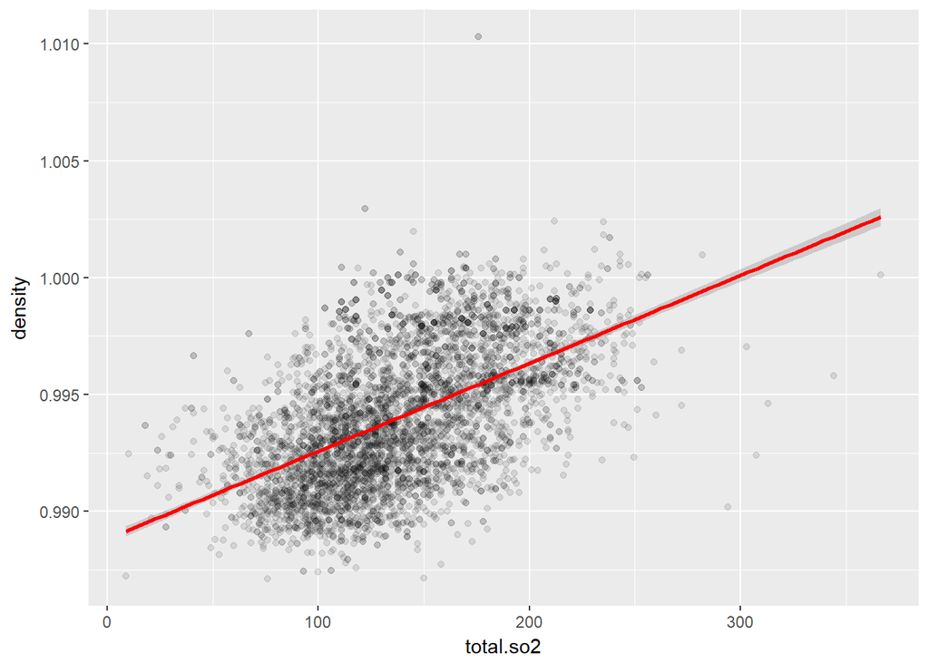

```
## [1] "Pearsons Correlation Coefficient: 0.544207"
```

The total sulfur dioxide seems to be correlated with the density. The Pearsons correlation coefficient is 0.54, which indicates a moderate to good positive correlation.

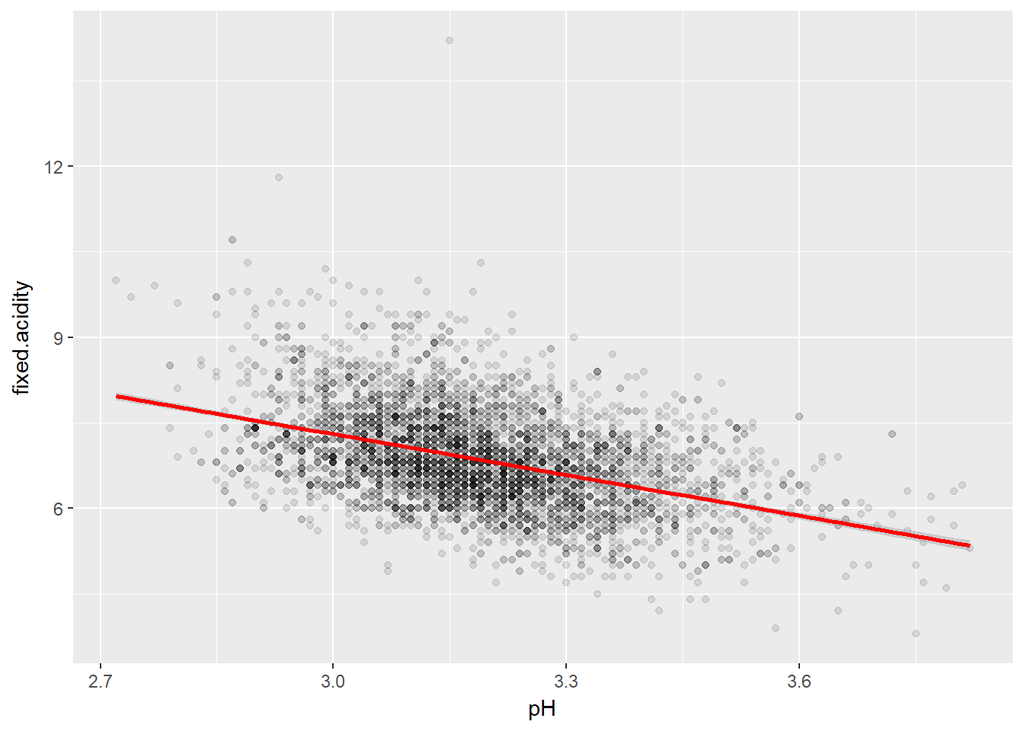